# Prosper Loan Data Exploration

### by (Azade Dehghanpour)

## Dataset

Dataset consist of **113,937** entries on loans borrowed through 'Prosper' peer-to-peer lending marketplace. Each entry (row) has **81** features (fields/columns) that describe certain attributes of the Borrower (Member), borrower's loan request(Listing), Lender(Investor), and the Loan itself including loan amount, borrower rate (or interest rate), current loan status, borrower income, and many others. Further elaboration on variables can be found at [Prosper API Definition Page](https://www.prosper.com/Downloads/Services/Documentation/ProsperAPI_Objects_Details.html).

## Main Areas of Interest in Dataset

- Makeup of Prosper customers (Borrowers)in terms of the level of their income (income range and monthly income), available credit and credit grade.
- Categories in which the members apply for loans (business, home improvement,...), size of the loan they usually borrow for the stated purpose and what repayment schedule they desire most ( 12,36 or 60 months)
- Relationship between certain features of members (monthly income, available credit, debt to income ratio) and Annual Percentage Rate(APR) they recieve.

## Dataset Features of Interest

- Income Range
- Stated Monthly Income
- Debt to Income Ratio
- Available Bankcard Credit
- Credit Grade
- Loan Original Amount
- Term
- Borrower APR

## Limitation

- **Listing Category** A significant portion of loans are listed under other or Not available. Therefore the analysis falls short of accurately make a statement on what the loans are borrowed for.
- **Credit Grade** For 85% of the entries this valuable indicator is not available. Though quite an important and interesting feature, lack of enough entries caused a degree of descrepency.

## Majority Groups in Dataset (Focus Data)

**Four income range categories** (\$25,000-49,999,\\$50,000-74,999,\$75,000-99,999,\\$100,000+) are the majority groups by number of loans **85%** of all the loans, and volum **~92%** of the total volume borrowed.  
*Members belonging to these four categories were the focus of this analysis*

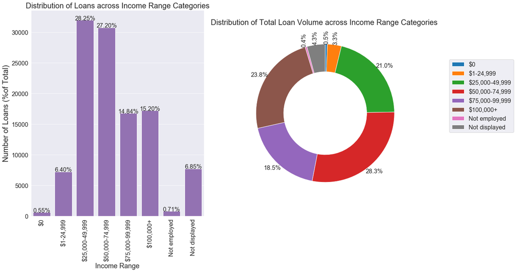

```python
#plt.style.context('fivethirtyeight')
plt.figure(figsize = (18,10))
plt.style.context('fivethirtyeight')

plt.subplot(121)
sb.countplot(data = clean_data, x = 'IncomeRange', color = base_color)
plt.xticks(size = 16,rotation = '90')
plt.yticks(size = 16)
plt.xlabel('Income Range' , size = 18)
plt.ylabel('Number of Loans (%of Total)' , size = 20)
plt.title('Distribution of Loans across Income Range Categories',size = 20)

IncomeRange_count = clean_data.IncomeRange.value_counts()
xtick_loc, xtick_label = plt.xticks()
all_IncomeRange_count = clean_data.IncomeRange.shape[0] - clean_data.IncomeRange.isna().sum()
for xt_loc, xt_lab in zip(xtick_loc, xtick_label):
    count_ony = IncomeRange_count[xt_lab.get_text()]
    plt.text(xt_loc,count_ony, '{:.2f}%'.format(100*count_ony/all_IncomeRange_count), ha = 'center',size = 16);

plt.subplot(122)
patches, texts, autotexts =plt.pie(total_loan_per_income_category.TotalLoan,startangle = 90, counterclock = False, autopct='%1.1f%%',pctdistance=1.1, labeldistance=2,wedgeprops = {'width' : 0.4}, textprops={'fontsize': 16})
plt.legend(labels = total_loan_per_income_category.IncomeRange, loc='center left', bbox_to_anchor=(1.2, 0.6), fontsize = 16);
plt.title('Distribution of Total Loan Volume across Income Range Categories ', size = 20, loc='center')
plt.setp(autotexts[0], size=16, rotation = '90')
plt.setp(autotexts[1], size=16, rotation = '90')
plt.setp(autotexts[6], size=16, rotation = '90')
plt.setp(autotexts[7], size=16, rotation = '90');
```

## Highly Desired Loan Categories

**Top 5 of desired loans** for each Income Range categories are as seen below. **Debt Consolidation** accounts for **56%** of total number of loans.  
*'Other' and 'Not Available' were discardered due to their un-informative nature.*

```python
focus_data.drop(focus_data[focus_data.CreditGrade == 'NC'].index,axis = 0, inplace = True)
```

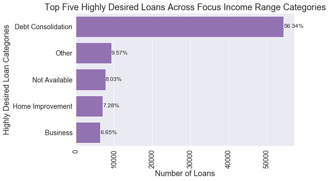

```python
plt.figure(figsize = (8,5))
sb.countplot(data = focus_data, y='ListingCategory', order = pd.value_counts(focus_data['ListingCategory']).iloc[:5].index, color = base_color)
ytick_loc1 ,ytick_lb1= plt.yticks()
for yt_loc1 ,yt_lb1 in zip(ytick_loc1 ,ytick_lb1):
    category_count1 = focus_data.ListingCategory.value_counts()[yt_lb1.get_text()]
    plt.text(category_count1,yt_loc1,  '{:.2f}%'.format(100*category_count1/focus_data.ListingCategory.shape[0]), va = 'center', size = 12)
plt.xticks(rotation = '90', size = 14)
plt.yticks( size = 14)
plt.ylabel('Highly Desired Loan Categories', size = 16)
plt.xlabel('Number of Loans', size = 16)
plt.title('Top Five Highly Desired Loans Across Focus Income Range Categories', size = 18);
```

## Repayment Term, Credit Grade and Highly Desired Loan across Income Categories

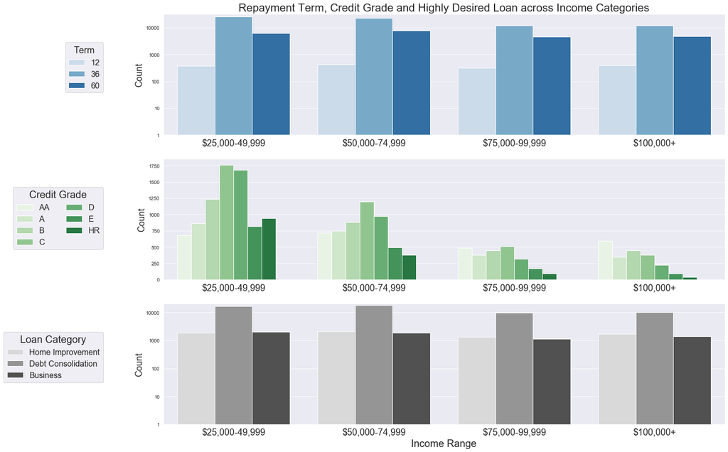

```python
fig, (ax1,ax2,ax3) = plt.subplots(3,1, figsize = (20,15))

#Term distribution for Incom category
sb.countplot(data = focus_data, x = 'IncomeRange', hue = 'Term', palette = 'Blues', ax = ax1)
xt_labels = ["$25,000-49,999","$50,000-74,999","$75,000-99,999","$100,000+"]
ax1.set_yscale('log')
ax1.set_yticks([1,10,100,1000,10000],[1,10,100,1000,10000])
ax1.get_yaxis().set_major_formatter(matplotlib.ticker.ScalarFormatter())
ax1.legend(bbox_to_anchor=(-0.1, 0.8), loc='best', ncol=1, title = 'Term', fontsize = 16)
ax1.get_legend().get_title().set_fontsize('18')
ax1.set_xlabel('')
ax1.set_xticklabels(labels =xt_labels, size = 18)
ax1.set_ylabel('Count',size = 18)
ax1.set_title('Repayment Term, Credit Grade and Highly Desired Loan across Income Categories', size = 22)
sb.countplot(data = focus_data, x = 'IncomeRange', hue = 'CreditGrade',palette = 'Greens', ax = ax2)
ax2.legend(['AA' , 'A' , 'B' , 'C' , 'D' , 'E' , 'HR'], bbox_to_anchor=(-0.1,0.8), loc='best', ncol=2, title = 'Credit Grade',  fontsize = 16)
ax2.get_legend().get_title().set_fontsize('20')
ax2.set_xlabel('')
ax2.set_xticklabels(labels =xt_labels, size = 18)
ax2.set_ylabel('Count',size = 18)



sb.countplot(data = desired_loans, x = 'IncomeRange' ,hue = 'ListingCategory',palette = 'Greys', ax = ax3)
ax3.legend( bbox_to_anchor=(-0.1, 0.8), loc='best', ncol=1, title = 'Loan Category', fontsize = 16)
ax3.get_legend().get_title().set_fontsize('20')
ax3.set_yscale('log')
ax3.set_yticks([1,10,100,1000,10000],[1,10,100,1000,10000])
ax3.get_yaxis().set_major_formatter(matplotlib.ticker.ScalarFormatter())
ax3.set_xticklabels(labels =xt_labels, size = 18)
ax3.set_ylabel('Count',size = 18)
ax3.set_xlabel('Income Range',size = 20);
```

## Distribution of Loan Original Amount, Stated Monthly Income, Debt To Income Ratio and Available Bancard Credit across Income Range

Higher income ranges are synonymous with

- Higher monthly income,
- Lower debt to income ratio,
- More available credit
- Lower APR
- Larger loans

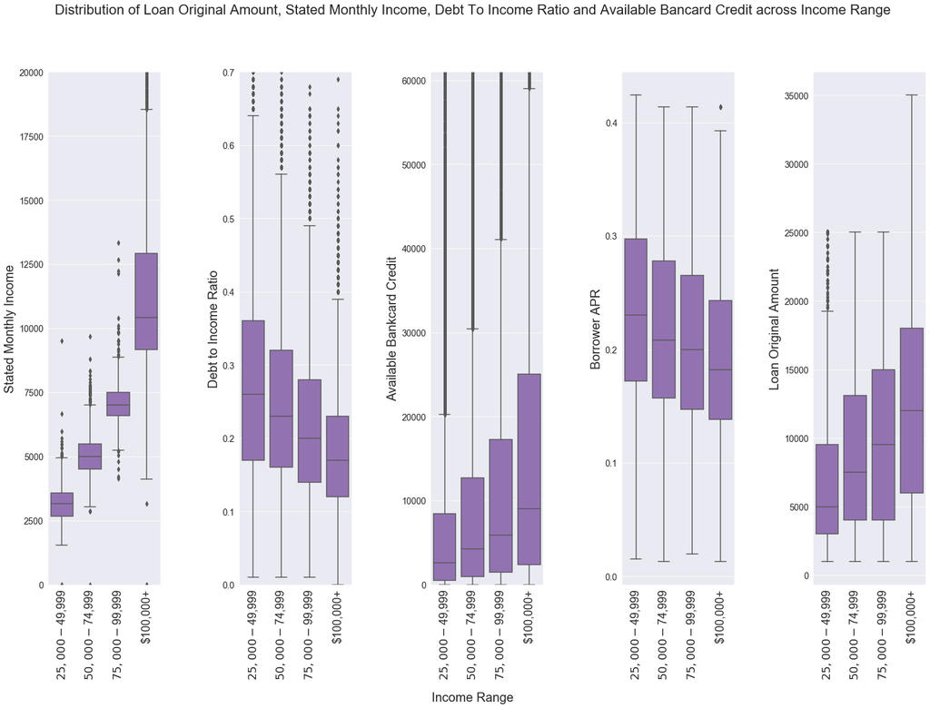

```python
fig, (ax1,ax2,ax3, ax4, ax5) = plt.subplots(1,5, figsize = (25,15))
fig.text(0.5, -0.05, 'Income Range',va = 'bottom',ha='center',size = 20)
plt.subplots_adjust(wspace=0.7, hspace=0.1)
fig.suptitle('Distribution of Loan Original Amount, Stated Monthly Income, Debt To Income Ratio and Available Bancard Credit across Income Range', ha = 'center' ,size=22)


xticks = ['$25,000-$49,999','$50,000-$74,999','$75,000-$99,999','$100,000+']
sb.boxplot(data = focus_data, x = 'IncomeRange', y='StatedMonthlyIncome', color = base_color,ax = ax1)
ax1.set_ylabel('Stated Monthly Income',size = 20)
ax1.set_ylim(0,20000)
ax1.set_xticklabels(labels=xticks,rotation = '90',size = 18)
ax1.set_xlabel('')
plt.setp(ax1.get_yticklabels(), fontsize=14)


sb.boxplot(data = focus_data, x = 'IncomeRange', y='DebtToIncomeRatio', color = base_color,ax = ax2)
ax2.set_ylabel('Debt to Income Ratio',size = 20)
ax2.set_ylim(0,0.7)
ax2.set_xticklabels(labels = xticks, rotation = '90',size = 18)
ax2.set_xlabel('')
plt.setp(ax2.get_yticklabels(), fontsize=14)


sb.boxplot(data = focus_data, x = 'IncomeRange', y='AvailableBankcardCredit', color = base_color,ax = ax3)
ax3.set_ylabel('Available Bankcard Credit',size = 20)
ax3.set_ylim(0,61000)
ax3.set_xticklabels(labels = xticks, rotation = '90',size = 18)
ax3.set_xlabel('')
plt.setp(ax3.get_yticklabels(), fontsize=14)


sb.boxplot(data = focus_data, x = 'IncomeRange', y='BorrowerAPR',color = base_color, ax = ax4)
ax4.set_ylabel('Borrower APR',size = 20)
ax4.set_xticklabels(labels = xticks, rotation = '90',size = 18)
ax4.set_xlabel('')
plt.setp(ax4.get_yticklabels(), fontsize=14)


sb.boxplot(data = focus_data, x = 'IncomeRange', y='LoanOriginalAmount', color = base_color,ax = ax5)
ax5.set_ylabel('Loan Original Amount',size = 20);
ax5.set_xticklabels(labels = xticks, rotation = '90',size = 18)
ax5.set_xlabel('')
plt.setp(ax5.get_yticklabels(), fontsize=14);
```

## Relationships among Features of Interest and Borrower APR

*Features of interest: Stated Monthly Income, Debt To Income Ratio, Available Bancard Credit, and Loan Original Amount*

- As APR improves, the volume of loans borrowed increases
- Increase in monthly income and available credit means better APR
- Higher debt to income ratio worsens APR
- Members with higher monthly incom and more credit available on their bank card, enjoy better APR.
- Available credit contributes most to improving APR.

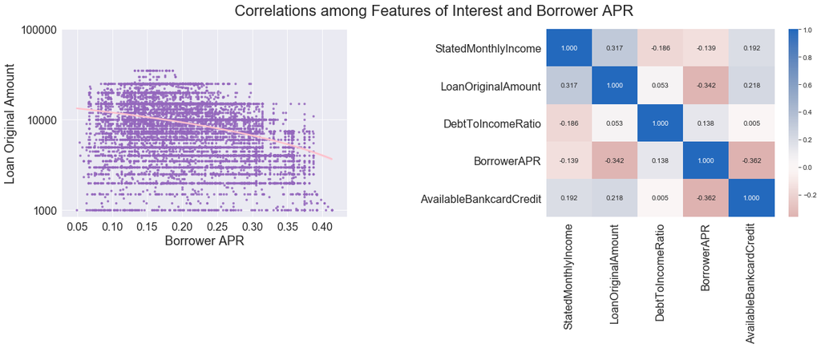

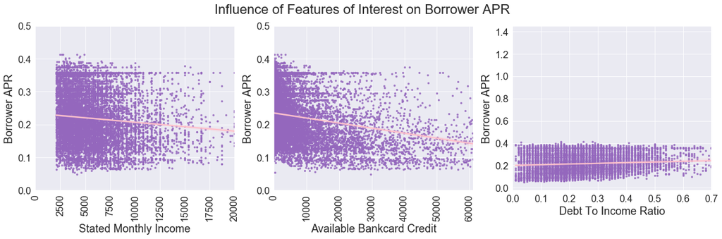

```python
plt.figure(figsize = (20,5))
plt.suptitle('Correlations among Features of Interest and Borrower APR', size = 22)
sample = focus_data.sample(10000)
plt.subplots_adjust(wspace=0.7, hspace=0.1)

plt.subplot(121)
sb.regplot(data = sample, x = 'BorrowerAPR', y = 'LoanOriginalAmount',line_kws={"color": "pink"}, color = base_color,scatter_kws={'s':6})
plt.yscale('log')
plt.yticks([1000,10000,100000],[1000,10000,100000],size = 16)
plt.xticks(size = 16)
plt.xlabel('Borrower APR',size = 18)
plt.ylabel('Loan Original Amount',size = 18)

plt.subplot(122)
sb.heatmap(sample[['StatedMonthlyIncome','LoanOriginalAmount','DebtToIncomeRatio','BorrowerAPR','AvailableBankcardCredit']].corr(), annot = True, fmt = '.3f',
           cmap = 'vlag_r', center = 0);
plt.xticks(size = 16)
plt.yticks(size = 16)


plt.subplots_adjust(wspace=0.7, hspace=0.1)
plt.figure(figsize = (20,5))
plt.suptitle('Influence of Features of Interest on Borrower APR', size = 22)
plt.subplot(131)
sb.regplot(data = sample, y = 'BorrowerAPR', x = 'StatedMonthlyIncome',line_kws={"color": "pink"},color = base_color,scatter_kws={'s':6})
plt.xlim(0,20000)
plt.ylim(0,0.5)
plt.xticks(rotation = 90, size = 16)
plt.yticks(size = 16)
plt.ylabel('Borrower APR',size = 18)
plt.xlabel('Stated Monthly Income',size = 18)

plt.subplot(132)
sb.regplot(data = sample, y = 'BorrowerAPR', x = 'AvailableBankcardCredit',line_kws={"color": "pink"},color = base_color,scatter_kws={'s':6})
plt.xlim(0,61000)
plt.ylim(0,0.5)
plt.xticks(rotation = 90, size = 16)
plt.yticks(size = 16)
plt.ylabel('Borrower APR',size = 18)
plt.xlabel('Available Bankcard Credit',size = 18)


plt.subplot(133)
sb.regplot(data = sample, y = 'BorrowerAPR', x = 'DebtToIncomeRatio',line_kws={"color": "pink"},color = base_color,scatter_kws={'s':6})
plt.xlim(0,0.7)
plt.xticks(size = 16)
plt.yticks(size = 16)
plt.ylabel('Borrower APR',size = 18)
plt.xlabel('Debt To Income Ratio',size = 18);
```

## Average Loan Amount of Income Categories across Different Terms, Credit Grades and Desired Loan Categories

- Although most members, as observed earliear, pay off their loans in 36months. It appears that , across all income range categories, 60month term is favored for repayment of higher loans.
- Average amount of loans borrowed is higher for members with better credit grade
- for the 3 highest income range category on average loans taken for debt consolidation is the largest while for members in 25000-49,999 income range larger average loan is borrowed for business.

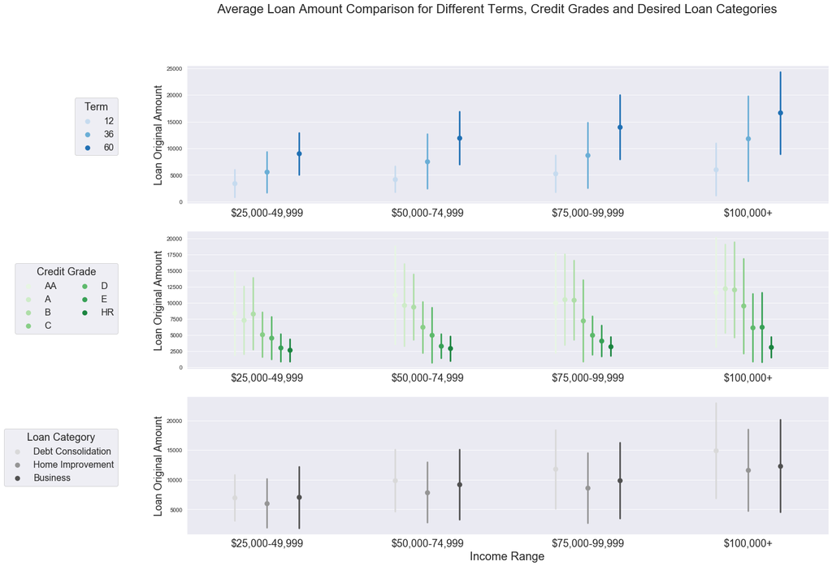

```python
fig, (ax1,ax2,ax3) = plt.subplots(3,1, figsize = (20,15))
plt.suptitle('Average Loan Amount Comparison for Different Terms, Credit Grades and Desired Loan Categories', size = 22)
sb.pointplot(data = sample, x = 'IncomeRange', y = 'LoanOriginalAmount',hue = 'Term',
           palette = 'Blues', linestyles = '', dodge = 0.4, ci='sd',ax = ax1)
ax1.legend(bbox_to_anchor=(-0.1, 0.8), loc='best', ncol=1, title = 'Term', fontsize = 16)
ax1.get_legend().get_title().set_fontsize('18')
ax1.set_xlabel('')
ax1.set_xticklabels(labels =xt_labels, size = 18)
ax1.set_ylabel('Loan Original Amount',size = 18)

sb.pointplot(data = sample, x = 'IncomeRange', y = 'LoanOriginalAmount',hue = 'CreditGrade',
           palette = 'Greens', linestyles = '', dodge = 0.4, ci='sd',ax = ax2)
leg_handles = ax2.get_legend_handles_labels()[0]
ax2.legend(leg_handles,['AA' , 'A' , 'B' , 'C' , 'D' , 'E' , 'HR'],bbox_to_anchor=(-0.1, 0.8), loc='best', ncol=2, title = 'Credit Grade', fontsize = 16)
ax2.get_legend().get_title().set_fontsize('18')
ax2.set_xlabel('')
ax2.set_xticklabels(labels =xt_labels, size = 18)
ax2.set_ylabel('Loan Original Amount',size = 18)

sample3 = desired_loans.sample(10000)
sb.pointplot(data = sample3, x = 'IncomeRange', y = 'LoanOriginalAmount',hue = 'ListingCategory',
           palette = 'Greys', linestyles = '', dodge = 0.4, ci='sd',ax = ax3)
ax3.legend(bbox_to_anchor=(-0.1, 0.8), loc='best', ncol=1, title = 'Loan Category', fontsize = 16)
ax3.get_legend().get_title().set_fontsize('18')
ax3.set_xticklabels(labels =xt_labels, size = 18)
ax3.set_ylabel('Loan Original Amount',size = 18)
ax3.set_xlabel('Income Range',size = 20);
```

# Influence of Features of Interest on APR across Income Range and Credit Grade

*Features of interest: Stated Monthly Income, Debt To Income Ratio, Available Bancard Credit, and Loan Original Amount*

# Influence of Debt to Income Ratio on APR

*In few cases data show out of character behavior. It is cause by randomness of data due to insufficient number of data points*

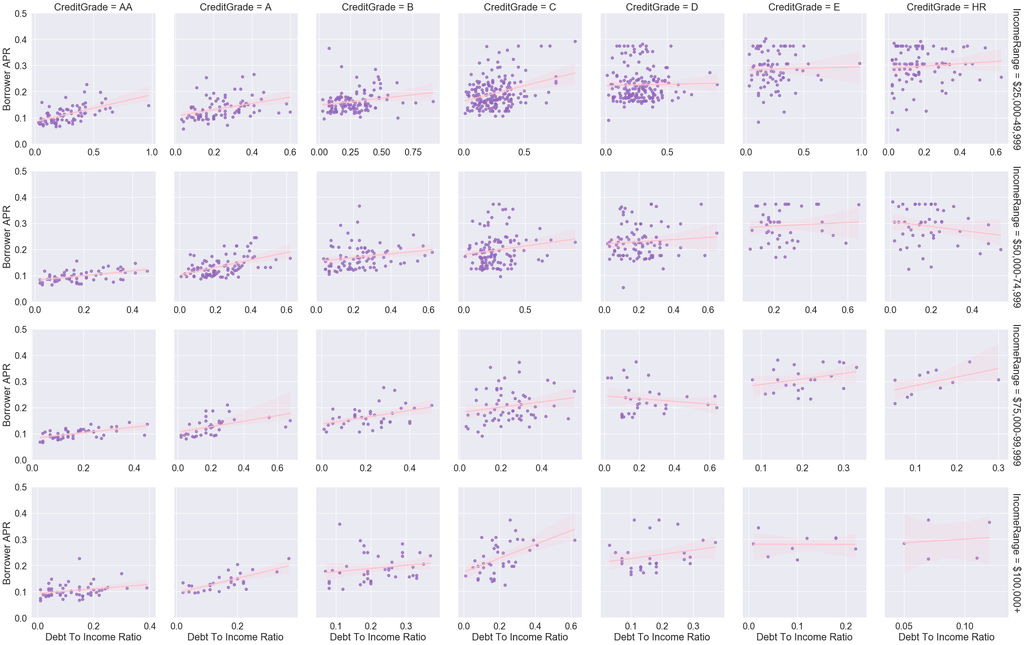

```python
sb.set(font_scale=1.8)
g=sb.FacetGrid(data=sample[(sample.DebtToIncomeRatio<=1)], aspect=0.9, height=5, margin_titles = True,row='IncomeRange', col ='CreditGrade',sharex=False)
g.map(sb.regplot, 'DebtToIncomeRatio','BorrowerAPR',  color = base_color,line_kws={'color':'pink'})
g.set(ylim = (0,0.5))
for i in range(7):
    g.axes[3,i].set_xlabel('Debt To Income Ratio', wrap = True)
for j in range(4):
    g.axes[j,0].set_ylabel('Borrower APR')
```

# Influence of Stated Monthly Income on APR

- Higher monthly income leads to better APR. However the influence appears to be minimal

*In few cases data show out of character behavior. It is cause by randomness of data due to insufficient number of data points*

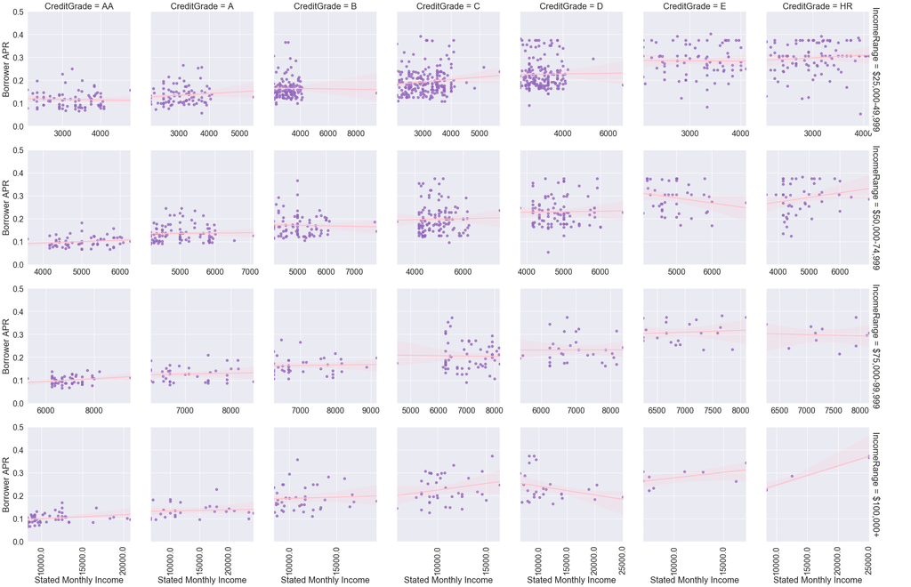

```python
sb.set(font_scale=1.8)
g=sb.FacetGrid(data=sample[(sample.StatedMonthlyIncome<=21000)], aspect=0.9, height=5, row='IncomeRange', col ='CreditGrade',margin_titles = True,sharex=False)
g.map(sb.regplot, 'StatedMonthlyIncome','BorrowerAPR',  color = base_color,line_kws={'color':'pink'})
g.set(ylim = (0,0.5))
g.add_legend()
for i in range(7):
    g.axes[3,i].set_xlabel('Stated Monthly Income', wrap = True)
    g.axes[3,i].set_xticklabels(labels = g.axes[3,0].get_xticks(),rotation = 90)
for j in range(4):
    g.axes[j,0].set_ylabel('Borrower APR');
```

# Influence of Available Bankcard Credit on APR

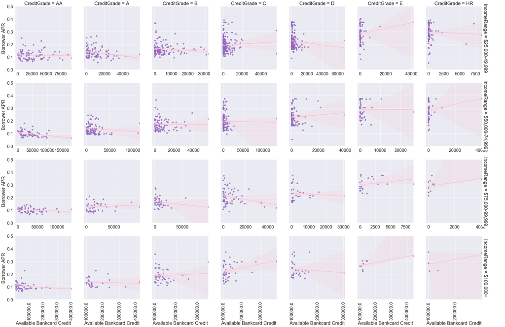

```python
sb.set(font_scale=1.8)
g=sb.FacetGrid(data=sample, margin_titles = True, aspect = 0.9, height=5,row='IncomeRange', col = 'CreditGrade',sharex=False)
g.map(sb.regplot, 'AvailableBankcardCredit','BorrowerAPR',  color = base_color,line_kws={'color':'pink'});
g.add_legend()
g.set(ylim = (0,0.5))
for i in range(7):
    g.axes[3,i].set_xlabel('Available Bankcard Credit', wrap = True)
    g.axes[3,i].set_xticklabels(labels = g.axes[3,0].get_xticks(),rotation = 90)
for j in range(4):
    g.axes[j,0].set_ylabel('Borrower APR');
```